# Visualization in R:

## `ggplot2` and `plotly`

Christina Maimone

# Workshop Outline

Visualization in R  
`ggplot`: Examples and Background  
What is Plotly?  
Let’s make some plots

# Visualization in R

## Built-in Base R Graphics

R comes with plotting functions built in.

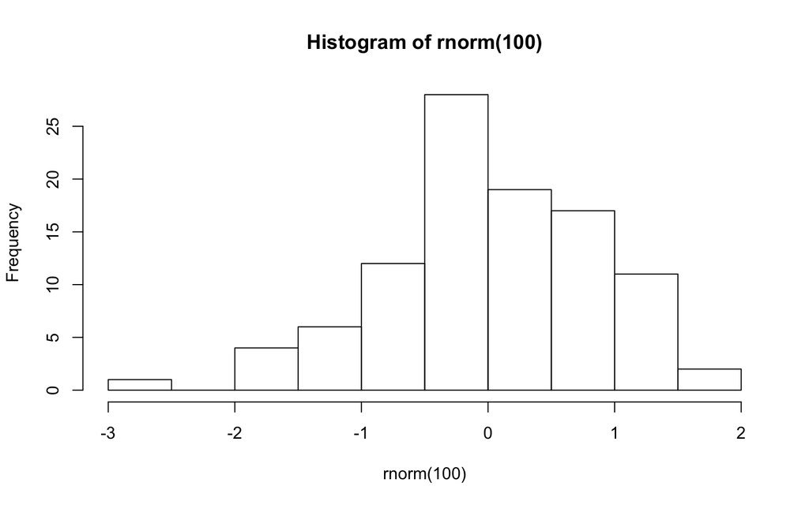

```r
hist(rnorm(100))
```

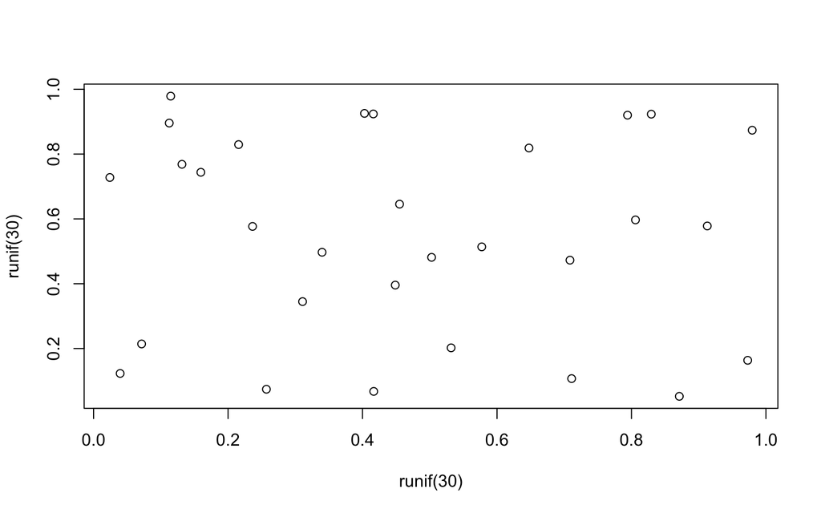

```r
plot(x=runif(30), y=runif(30))
```

- Good for a lot of situations
- But they often aren’t very attractive
- Grouping is difficult
- Legends can be tricky and aren’t automatic
- Different plots are made in different ways

## R Plotting Systems

- base graphics
- `ggplot2`
- `lattice`: around for a long time, not widely used
- `ggvis`: builds on `ggplot2`, extending for interactive graphics, but not complete yet

## Additional Visualization Packages

- `plotly`
- `igraph`: for network graphs
- `ggmap` and `leaflet`: maps (other packages for this too)
- `googleVis`: Google Charts API
- `rgl`: 3D plots
- `dygraphs`: interactive time series

Other specialized packages for fields such as genomics

# ggplot

Let’s start with the same plots as before

```r
library(ggplot2)
```

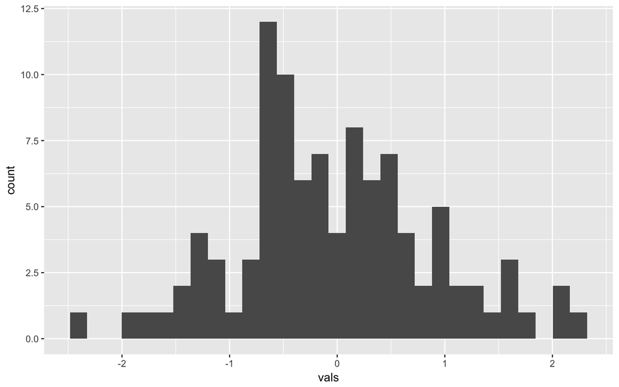

```r
mydata<-data.frame(vals=rnorm(100)) ## ggplot expects a data.frame
ggplot(mydata, aes(vals))+geom_histogram()
```

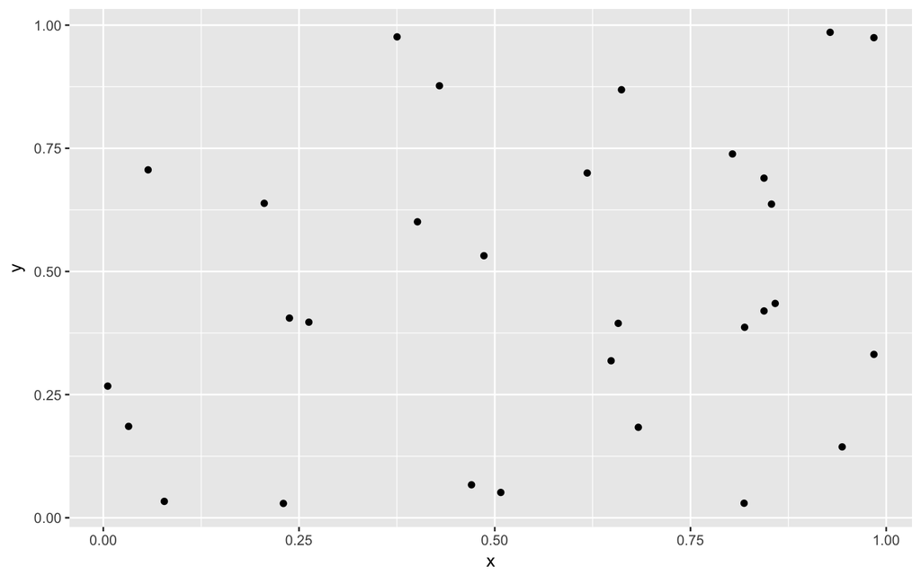

```r
mydata<-data.frame(x=runif(30), y=runif(30))
ggplot(mydata, aes(x, y))+geom_point()
```

Those look a little better (maybe)…

But the code is more complicated

## Could use the `qplot` shorcut

`qplot` is a `ggplot2` function

Works a lot the base graphics `plot`

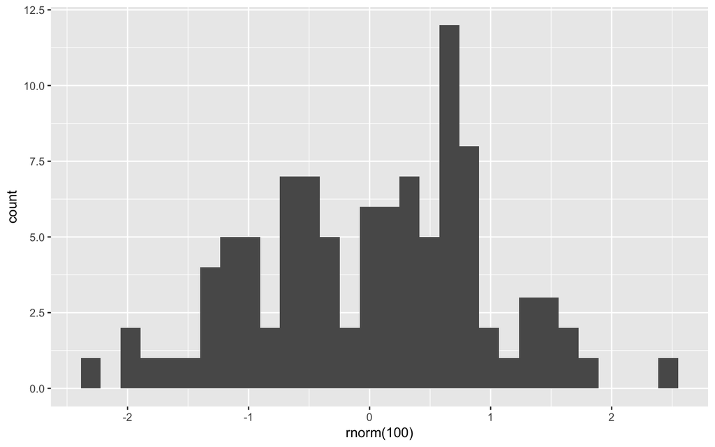

```r
qplot(rnorm(100))
```

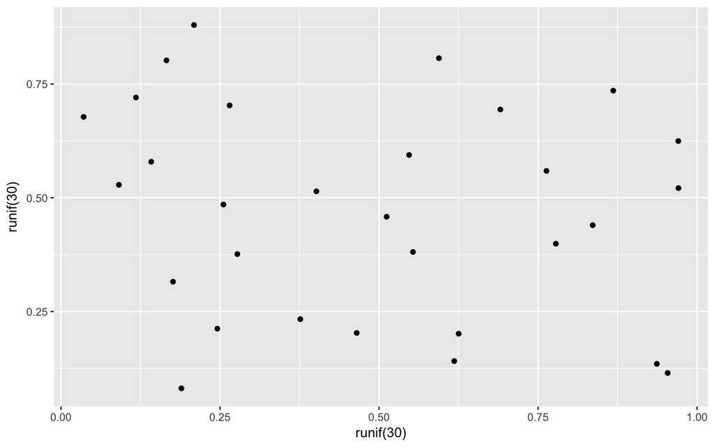

```r
qplot(runif(30), runif(30))
```

But we’re going to ignore `qplot` and only use `ggplot` to avoid confusion

## Better Examples

`ggplot` is most useful for more complicated plots

Basic Scatterplot

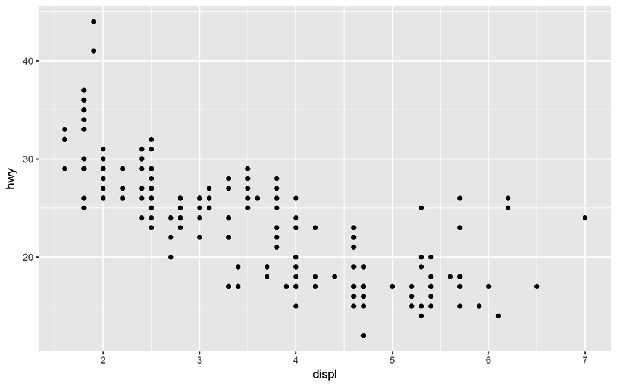

```r
# using mpg data set that comes with ggplot2
ggplot(mpg, aes(displ, hwy)) + geom_point()
```

Add a third dimension with color

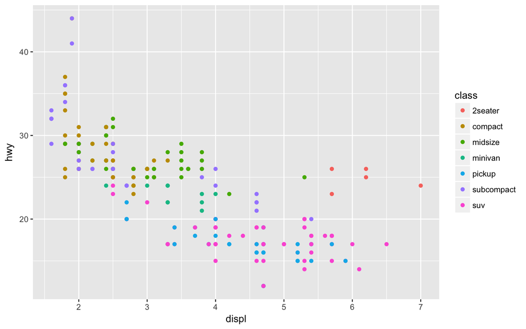

```r
ggplot(mpg, aes(displ, hwy, colour = class)) + geom_point()
```

Add linear trend lines by class

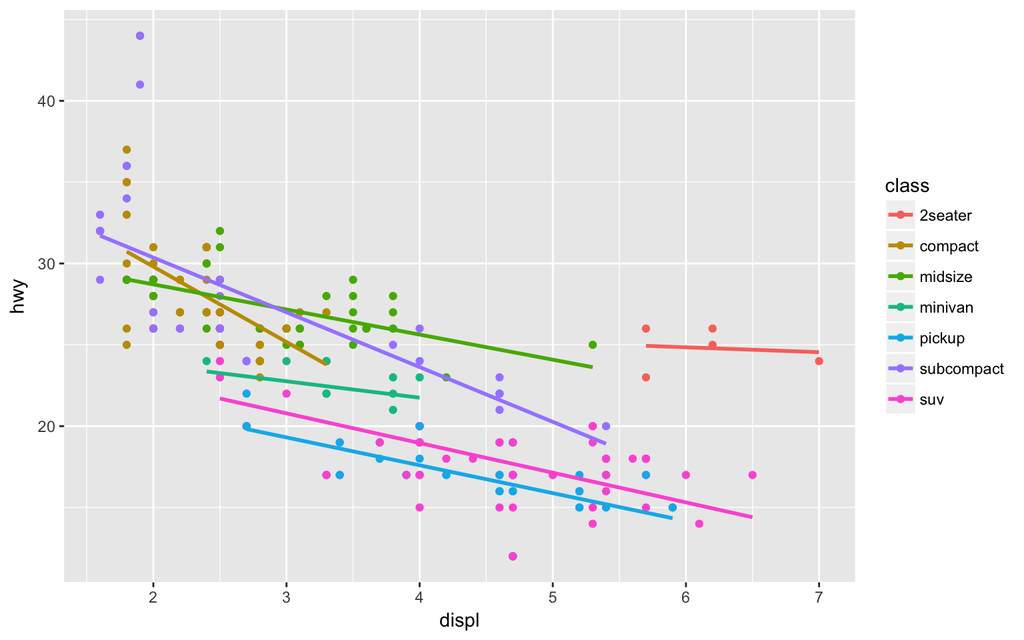

```r
ggplot(mpg, aes(displ, hwy, colour = class)) +
  geom_point() + geom_smooth(method="lm", se=FALSE)
```

Separate by class

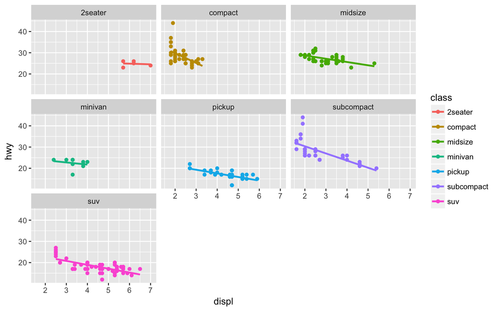

```r
ggplot(mpg, aes(displ, hwy, colour = class)) +
  geom_point() + geom_smooth(method="lm", se=FALSE) +
  facet_wrap(~class)
```

## `ggplot` or `ggplot2`?

The name of the package is `ggplot2`.

The name of the function used to create a plot is `ggplot`.

## But…

You’ll see `ggplot` used to refer to the whole system as well (as I do here). `ggplot2` started with `ggplot`, which isn’t used anymore.

## What makes up a `ggplot` plot?

## Data

`ggplot(mpg)`

a `data.frame` to use

## Aesthetics

`ggplot(mpg,` `aes(x=displ, y=hwy, color=class)``)`

position (x, y)  
size • color • shape  
fill • linetype • transparency

See https://cran.r-project.org/web/packages/ggplot2/vignettes/ggplot2-specs.html

## Geoms

`ggplot(mpg, aes(x=displ, y=hwy, color=class)) +`  
`geom_point()`

What type of plot to draw?

One or two variables?

Discrete or continuous values?

## Other Components

- **Coordinates**: the grid you’re plotting on
- **Stats**: transformations of the data
- **Scales**: breaks, colors, labels, transformations
- **Facets**: plots for different groups
- **Labels**: title, axes
- **Themes**: overall style

# Plotly

## Use Plotly for

- Interactive graphics
- Sharing plots online
- Editable plots (zoom, select observations, etc.)
- Teams working in multiple languages (MATLAB, R, Python, JavaScript)

https://plot.ly/~RPlotBot/3260.embed

# Code

This presentation and the code we’re using are available at https://www.github.com/nuitrcs/ggplotworkshop/